# hw_2

Ruizhou Peng

2023-10-16

## Preparations

If there is no packages needed for this assignment, firstly install them in console

```r
library(tidyverse)
library(Stat2Data)
data("Hawks")
```

we can see the first few rows of the data “Hawks”

```r
head(Hawks)
```

```
##   Month Day Year CaptureTime ReleaseTime  BandNumber Species Age Sex Wing
## 1     9  19 1992       13:30               877-76317      RT   I      385
## 2     9  22 1992       10:30               877-76318      RT   I      376
## 3     9  23 1992       12:45               877-76319      RT   I      381
## 4     9  23 1992       10:50               745-49508      CH   I   F  265
## 5     9  27 1992       11:15              1253-98801      SS   I   F  205
## 6     9  28 1992       11:25             1207-55910       RT   I      412
##   Weight Culmen Hallux Tail StandardTail Tarsus WingPitFat KeelFat Crop
## 1    920   25.7   30.1  219           NA     NA         NA      NA   NA
## 2    930     NA     NA  221           NA     NA         NA      NA   NA
## 3    990   26.7   31.3  235           NA     NA         NA      NA   NA
## 4    470   18.7   23.5  220           NA     NA         NA      NA   NA
## 5    170   12.5   14.3  157           NA     NA         NA      NA   NA
## 6   1090   28.5   32.2  230           NA     NA         NA      NA   NA
```

## 1. Data Wrangling

### 1.1 select and filter

generate a data frame called ‘hSF’ which is a sub-table of the original Hawks, such that:

1. Your data frame should include the columns:
1. “Wing”
2. “Weight”
3. “Tail”
2. Your data frame should contain a row for every hawk such that:
1. They belong to the species of Red-Tailed hawks
2. They have weight at least 1kg.
3. Use the pipe operator “%>%” to simplify your code.

```r
# simple version
# firstly filter rows of species and weight
new_temp_table <- filter(Hawks, Species=='RT'&Weight>=1000)
# then select columns
hSF <- select(new_temp_table, Wing, Weight, Tail)
```

check the answer:

```r
head(hSF)
```

```
##   Wing Weight Tail
## 1  412   1090  230
## 2  412   1210  210
## 3  405   1120  238
## 4  393   1010  222
## 5  371   1010  217
## 6  390   1120  213
```

now use pipe operator to simplify code

```r
hSF2 <- Hawks%>%
  filter(Species=="RT"&Weight>=1000)%>%
  select(Wing, Weight, Tail)
```

check the answer:

```r
head(hSF2)
```

```
##   Wing Weight Tail
## 1  412   1090  230
## 2  412   1210  210
## 3  405   1120  238
## 4  393   1010  222
## 5  371   1010  217
## 6  390   1120  213
```

according to the table, hSF has 3 variables and 398 observations(examples and cases?), I would like to say that this information tells us about the Wing, Tail relationship of the Red-tailed hawks which weight is at least 1kg.

### 1.2 The arrange function

use arrange to sort hSF so that the rows appear in order of increasing wing span

```r
hSF<- arrange(hSF, Wing)
```

check

```r
head(hSF)
```

```
##    Wing Weight Tail
## 1  37.2   1180  210
## 2 111.0   1340  226
## 3 199.0   1290  222
## 4 241.0   1320  235
## 5 262.0   1020  200
## 6 277.0   1500  207
```

### 1.3 Join and rename

q1: use **data.frame** to create a data frame called **hawkSpeciesNameCodes**

q2: use combination of the function **left_join**, **rename** and **select** to create a new data frame called “hawksFullName” which is the same as the “Hawks” data frame except that the Species column contains the full names rather than the two-letter codes

q3: use a combination of the **head** and **select** to print out the top seven rows of the columns “Species”, “Wing” and “Weight” of the data frame called “hawksFullName” without modifying the data frame just created

```r
# first create the nameCode frame
species_code <- c('CH', 'RT', "SS")
species_name_full <- c("Cooper's", "Red-Tailed", "Sharp-shinned")
hawkSpeciesNameCodes <- data.frame(species_code, species_name_full)
```

```r
# use left_join, rename and select to create a new frame
# rename(new_name=old_name)
hawksFullName <- Hawks%>%
      left_join(rename(hawkSpeciesNameCodes, Species=species_code))%>%
      select(-Species)%>%
      rename(Species=species_name_full)
# use head and select to show top seven rows "Species","Wing" and "Weight"

hawksFullName%>%
  select(Species, Wing, Weight)%>%
  head(7)
```

```
##         Species Wing Weight
## 1    Red-Tailed  385    920
## 2    Red-Tailed  376    930
## 3    Red-Tailed  381    990
## 4      Cooper's  265    470
## 5 Sharp-shinned  205    170
## 6    Red-Tailed  412   1090
## 7    Red-Tailed  370    960
```

using different join in this case has no difference, it will when the NameCodes frame don’t match exactly the Species in the Hawks frame.

### 1.4 Mutate function

The “bird BMI” is equal to the weight of the hawk (in grams) divided by their wing span (in millimeters) squared. That is

$$Bird-BMI:=1000*Weight/Wing-pan^2$$

q1: use **mutate**, **select** and **arrange** to create a new frame which has the same number of rows but only two columns. Arrange rows in descending order of BMI.

```r
hawksWithBMI<- Hawks%>%
  mutate(bird_BMI = 1000*Weight/(Wing*Wing))%>%
  select(Species, bird_BMI)%>%
  arrange(desc(bird_BMI))
```

check

```r
head(hawksWithBMI, 8)
```

```
##   Species  bird_BMI
## 1      RT 852.69973
## 2      RT 108.75741
## 3      RT  32.57493
## 4      RT  22.72688
## 5      CH  22.40818
## 6      RT  19.54932
## 7      CH  15.21998
## 8      RT  14.85927
```

### 1.5 Summarize and group-by

use hawksFullName do the following tasks

q1: using **summarize** and **group_by** create a summary table, broken down by species, which contains the following quantities:  
a) number of rows–>num_rows  
b) average wing span in centimeters –> mn_wing  
c) median wing span in centimeters –> nd_wing  
d) trimmed average wing span in centimeters with trim=0.1(lowest 10% and highest 10% removed) --> t_mn_wing  
e) biggest ratio between wing span and tail length –>b_wt_ratio

```r
hawksFullName%>%
  group_by(Species)%>%
  summarise(num_rows=n(),
            mn_wing=mean(Wing),
            md_wing=median(Wing, na.rm=TRUE),
            t_mn_wing=mean(Wing, trim=0.1),
            b_wt_ratio=max(Wing/Tail, na.rm = TRUE))
```

```
## # A tibble: 3 × 6
##   Species       num_rows mn_wing md_wing t_mn_wing b_wt_ratio
##   <chr>            <int>   <dbl>   <dbl>     <dbl>      <dbl>
## 1 Cooper's            70     NA      240       NA        1.67
## 2 Red-Tailed         577    383.     384      385.       3.16
## 3 Sharp-shinned      261    185.     191      184.       1.67
```

q2: show the number of missing values, broken down by species. Can complete this task by combining **select**, **group_by**, **summarize**, **across**, **everything**, **sum** and **is.na**

```r
hawksFullName%>%
  group_by(Species)%>%
  select(Species,Wing, Weight, Culmen, Hallux, Tail, StandardTail,
         Tarsus, Crop)%>%
  summarise(across(everything(), ~sum(is.na(.x))))
```

```
## # A tibble: 3 × 9
##   Species        Wing Weight Culmen Hallux  Tail StandardTail Tarsus  Crop
##   <chr>         <int>  <int>  <int>  <int> <int>        <int>  <int> <int>
## 1 Cooper's          1      0      0      0     0           19     62    21
## 2 Red-Tailed        0      5      4      3     0          250    538   254
## 3 Sharp-shinned     0      5      3      3     0           68    233    68
```

```r
# ~sum(is.na(.x)) <===> function(x){sum(is.na(x))}
```

across使用教程：https://bookdown.org/wangminjie/R4DS/tidyverse-beauty-of-across1.html

## 2. Tidy data and iteration

### 2.1 missing data and iteration

q1: the following function performs imputation by mean. Which library do we need to load to run this function?

```r
impute_by_mean <- function(x){
  mu <- mean(x, na.rm=TRUE)  # first compute the mean of x
  impute_f <- function(z){
    # coordinate-wise imputation
    if(is.na(z)){
      return(mu)
    }else{
      return(z)
    }
  }

  return(map_dbl(x, impute_f)) # apply the map function to impute across vector
}
```

ans: it need **tidyverse** library to run this function

q2: create a function called **impute_by_median** which imputes missing values based on the median of the sample.

```r
impute_by_median <- function(x){
  me <- median(x, na.rm=TRUE) # first compute median
  impute_f <- function(z){
    # impute coordinate-wisely
    if(is.na(z)){
      return(me)
    }else{
      return(z)
    }
  }

  return(map_dbl(x, impute_f))  # apply the map function to impute across vector
}
```

check

```r
v <- c(1,2,NA,4)
impute_by_median(v)
```

```
## [1] 1 2 2 4
```

q3: generate a data frame with two variables x and y. For x we have a sequence (x1,x2,…,xn) where x1=0, xn=10 and for each i=1…n-1,**x<sub>i+1</sub>=x<sub>i</sub>+0.1** For y we set **y<sub>i</sub> = 5x<sub>i</sub> +1**. Generate data of this form and place within a data frame called **df_xy**

```r
seq_x <- seq(0, 10, 0.1)
seq_y <- seq_x %>% map(~5*.x+1) %>% unlist() # if do not unlist, then seq_y is a list not a sequence, such that each element of seq_y is a seq(?)
df_xy <- data.frame(x=seq_x, y=seq_y)
```

check

```r
df_xy %>% head(5)
```

```
##     x   y
## 1 0.0 1.0
## 2 0.1 1.5
## 3 0.2 2.0
## 4 0.3 2.5
## 5 0.4 3.0
```

q4: the **map2** function is similar to **map**,but iterates over two variables in parallel rather than one. learn from here https://purrr.tidyverse.org/reference/map2.html. Following example shows how **map2_dbl** can be combined with the **mutate** function

```r
df_xy %>%
  mutate(z=map2_dbl(seq_x, seq_y, ~ .x + .y))%>%
  head(5)
```

```
##     x   y   z
## 1 0.0 1.0 1.0
## 2 0.1 1.5 1.6
## 3 0.2 2.0 2.2
## 4 0.3 2.5 2.8
## 5 0.4 3.0 3.4
```

now use **map2_dbl** to generate a new data frame with missing data

first create a function **sometimes_missing** with two arguments: index and value, return NA is index is divisible by 5 and return value otherwise

```r
sometimes_missing <- function(index, value){
  if(index%%5 == 0){
    return(NA)
  }else{
    return(value)
  }
}
```

next generate a data frame called **df_xy_missing** with x and y, but sometimes missing data. For x it is the same as df_xy, for y we have y<sub>i</sub> missing when i is divisible by 5 or otherwise equals to df_xy. Hint: maybe need to use **row_number**, **map2_dbl**, **mutate** and **sometimes_missing**

```r
df_xy_missing <- df_xy%>%
  mutate(y=map2_dbl(row_number(y), y,
                    sometimes_missing)
         )
```

check

```r
df_xy_missing %>% head(10)
```

```
##      x   y
## 1  0.0 1.0
## 2  0.1 1.5
## 3  0.2 2.0
## 4  0.3 2.5
## 5  0.4  NA
## 6  0.5 3.5
## 7  0.6 4.0
## 8  0.7 4.5
## 9  0.8 5.0
## 10 0.9  NA
```

q5: generate a new data frame **df_xy_imputed** with x, y. For y we have missing values imputed by median. use **impute_by_median** and **mutate** to impute from frame **df_xy_missing**

```r
df_xy_imputed <- df_xy_missing%>%
  mutate(y=impute_by_median(y))
```

check

```r
df_xy_imputed %>% head(6)
```

```
##     x    y
## 1 0.0  1.0
## 2 0.1  1.5
## 3 0.2  2.0
## 4 0.3  2.5
## 5 0.4 26.0
## 6 0.5  3.5
```

### 2.2 Tidying data with pivot functions

first download the excel spreadsheet “HockeyLeague.xlsx”. To read this spreadsheet into R shall make use of the **readxl** library.

To read in a sheet within an excel file as a data frame, need to edit the folder_path.

```r
library(readxl)  # load the readxl library
folder_path <- "./"

file_name <- "HockeyLeague.xlsx"
file_path <- paste(folder_path, file_name, sep="")
wins_data_frame <- read_excel(file_path, sheet="Wins")
```

inspect the first 3 rows of the first 5 columns:

```r
wins_data_frame %>%
  select(1:5)%>%
  head(3)
```

```
## # A tibble: 3 × 5
##   ...1   `1990`   `1991`   `1992`   `1993`
##   <chr>  <chr>    <chr>    <chr>    <chr>
## 1 Ducks  30 of 50 11 of 50 30 of 50 12 of 50
## 2 Eagles 24 of 50 12 of 50 37 of 50 14 of 50
## 3 Hawks  20 of 50 22 of 50 33 of 50 11 of 50
```

I think it is not a tidy data because the columns describe a single variable: year. And the cell is not a single value, it is combined by winning games and total games.

the definition of tidy data and how to tidy data is taught in the following link:  
https://tidyr.tidyverse.org/articles/tidy-data.html#defining

q1: transform the **wins_data_frame** into a data frame called **wins_tidy** which contains the same information but has just four columns entitled: “Team”, “Year”, “Wins”, “Total”. Hint: can do this by using **rename**, **pivot_longer**, **mutate** and **separate**

```r
# the point is use of rename: new_n=old_n
# and how to use pivot_longer:
#   cols---> choose columns to pivot
#   names_to---> the original columns gathered into a variable
#   values_to---> the value corespond to every original column
# use of seperate:
#   value---> choose a column to separate
#   c() ---> separate result columns
#   sep ---> separate sign
# mutate: can be use to change the type of columns
wins_tidy <- wins_data_frame%>%
  rename(Team=...1)%>%
  pivot_longer(cols=!'Team', names_to='Year', values_to = 'value') %>%
  separate(value, c('Wins', 'Total'), sep=' of ', convert= TRUE)%>%
  mutate(Year=as.integer(Year))
```

check

```r
wins_tidy %>% dim()
```

```
## [1] 248   4
```

```r
wins_tidy %>% head(5)
```

```
## # A tibble: 5 × 4
##   Team   Year  Wins Total
##   <chr> <int> <int> <int>
## 1 Ducks  1990    30    50
## 2 Ducks  1991    11    50
## 3 Ducks  1992    30    50
## 4 Ducks  1993    12    50
## 5 Ducks  1994    24    50
```

q2: read again “HockeyLeague.xlsx” with a sheet of losses and apply the similar procedure to transform it into a frame called “losses_tidy”

```r
losses_data_frame <- read_excel(file_path, sheet= "Losses")
```

then transform it into a tidy frame

```r
# the point is use of rename: new_n=old_n
# and how to use pivot_longer:
#   cols---> choose columns to pivot
#   names_to---> the original columns gathered into a variable
#   values_to---> the value corespond to every original column
# use of seperate:
#   value---> choose a column to separate
#   c() ---> separate result columns
#   sep ---> separate sign
# mutate: can be use to change the type of columns
losses_tidy <- losses_data_frame%>%
  rename(Team= ...1)%>%
  pivot_longer(cols=!'Team', names_to= 'Year', values_to= 'value')%>%
  separate(value, c('Losses', 'Total'), sep='of', convert=TRUE)%>%
  mutate(Year=as.integer(Year))
```

check

```r
losses_tidy %>% head(5)
```

```
## # A tibble: 5 × 4
##   Team   Year Losses Total
##   <chr> <int>  <dbl> <int>
## 1 Ducks  1990     20    50
## 2 Ducks  1991     37    50
## 3 Ducks  1992      1    50
## 4 Ducks  1993     30    50
## 5 Ducks  1994      7    50
```

q3: combine two frames into a single frame entitled ‘hockey_df’

```r
# the point is how to use .name in across and
# c() to choose columns to across
hockey_df <- inner_join(wins_tidy,
                        losses_tidy)%>%
    mutate(Draws=Total-(Wins+Losses))%>%
    mutate(across(c('Wins', 'Losses', 'Draws'),~.x/Total, .names="{.col}_rt"))
```

check

```r
hockey_df %>% head(5)
```

```
## # A tibble: 5 × 9
##   Team   Year  Wins Total Losses Draws Wins_rt Losses_rt Draws_rt
##   <chr> <int> <int> <int>  <dbl> <dbl>   <dbl>     <dbl>    <dbl>
## 1 Ducks  1990    30    50     20     0    0.6       0.4      0
## 2 Ducks  1991    11    50     37     2    0.22      0.74     0.04
## 3 Ducks  1992    30    50      1    19    0.6       0.02     0.38
## 4 Ducks  1993    12    50     30     8    0.24      0.6      0.16
## 5 Ducks  1994    24    50      7    19    0.48      0.14     0.38
```

q4: to conclude generate a summary data frame which displays the median win rate, the mean win rate, etc for each team. Rows represent teams, and sorted in descending order on median win rate. Hint: may use **select**, **group_by**, **across** and **arrange**

```r
# key point is use select to generate new name for each col
# use of multifunctions in across and each function can be named
# use {.fn} to refer each function name
sum_table <- hockey_df%>%
  select(Team, W=Wins_rt, L=Losses_rt, D=Draws_rt)%>%
  group_by(Team)%>%
  summarise(across(everything(),
                   list(md=~median(.x),
                        mn=~mean(.x)),
                   .names = "{.col}_{.fn}")
            )%>%
  arrange(desc(W_md))
```

check

```r
sum_table
```

```
## # A tibble: 8 × 7
##   Team         W_md  W_mn  L_md  L_mn  D_md  D_mn
##   <chr>       <dbl> <dbl> <dbl> <dbl> <dbl> <dbl>
## 1 Eagles      0.45  0.437 0.25  0.279 0.317 0.284
## 2 Penguins    0.45  0.457 0.3   0.310 0.133 0.232
## 3 Hawks       0.417 0.388 0.233 0.246 0.32  0.366
## 4 Ducks       0.383 0.362 0.34  0.333 0.25  0.305
## 5 Owls        0.32  0.333 0.3   0.33  0.383 0.337
## 6 Ostriches   0.3   0.309 0.4   0.395 0.267 0.296
## 7 Storks      0.3   0.284 0.22  0.283 0.48  0.433
## 8 Kingfishers 0.233 0.245 0.34  0.360 0.4   0.395
```

## 3. Visualization

using ggplot2 to visualize.

q1: use a combination of **filter**, **ggplot** and **geom_histogram** to create a plot of the **Wins of Ducks** with bin widths of 3

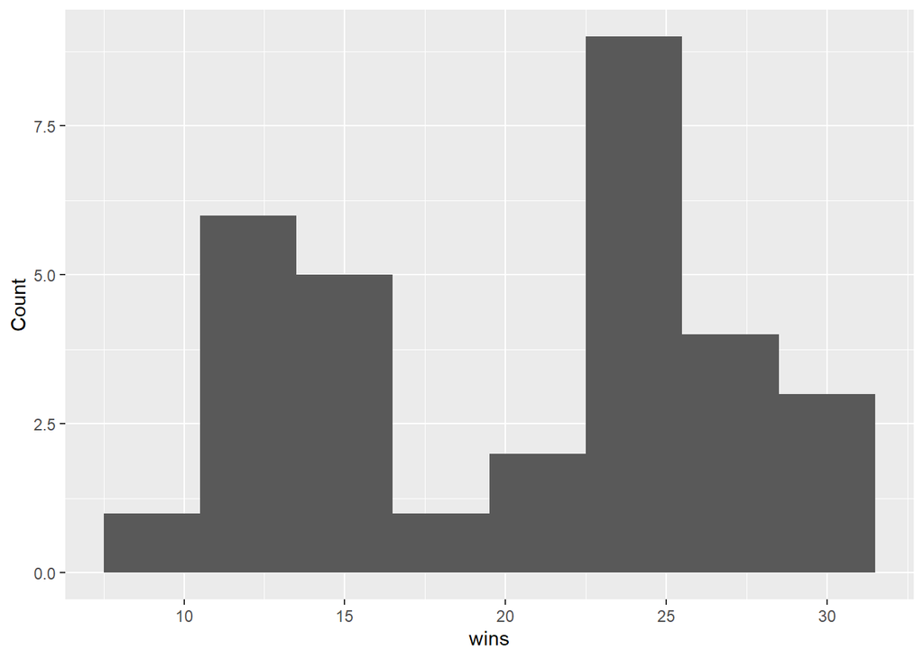

```r
# aes(x=?, y=?), in this case only need x aes
wins_tidy %>% filter(Team=='Ducks')%>%
  ggplot(aes(Wins))+geom_histogram(binwidth = 3)+xlab('wins')+ylab('Count')
```

q2: use **geom_density** to create two density plots with parameters **adjust=0.5** and **adjust=2**

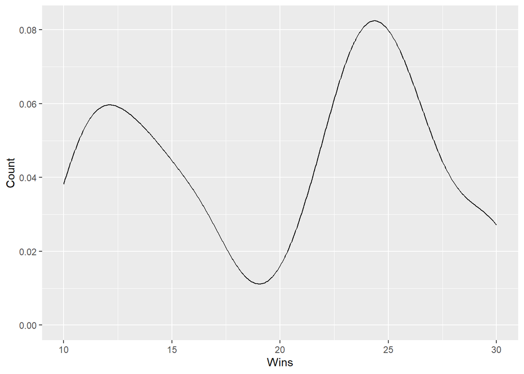

```r
wins_tidy %>% filter(Team=='Ducks')%>%
  ggplot(aes(Wins))+geom_density(adjust=0.5)+ylab('Count')
```

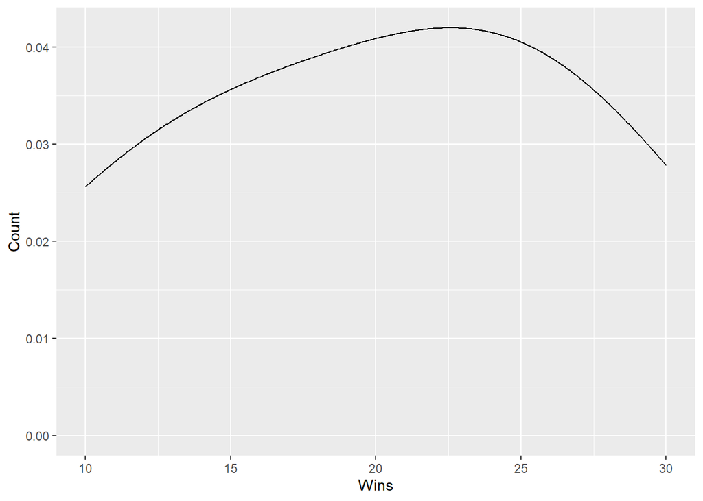

```r
wins_tidy %>% filter(Team=='Ducks')%>%
  ggplot(aes(Wins))+geom_density(adjust=2)+ylab('Count')
```

the difference between two plots is the former plot has 2 mode but the latter has only 1 mode. Moreover, the former plot’s modes density are more higher than the latter plot’s mode.

q3: create a bivariate plot. Transform **wins_tidy** to **wins_teams**, to show each team’s wins in every game year. Hint: use **select** and **pivot_wider**

```r
# pivot_wider is on the contrary of pivot_longer
#   names_from ---> new columns based on which original column
#   values_from ---> new cell value based on which original column
wins_teams <- wins_tidy %>%
  select(-Total)%>%
  pivot_wider(names_from = Team, values_from = Wins)
```

check

```r
wins_teams
```

```
## # A tibble: 31 × 9
##     Year Ducks Eagles Hawks Kingfishers Ostriches  Owls Penguins Storks
##    <int> <int>  <int> <int>       <int>     <int> <int>    <int>  <int>
##  1  1990    30     24    20          16        13    19       23     20
##  2  1991    11     12    22          19        13    13       29     13
##  3  1992    30     37    33          12        10    18       30     18
##  4  1993    12     14    11          10        25    16       32     22
##  5  1994    24     32    20          17        10    13       33     19
##  6  1995    13     34    18          11        21    24       36     11
##  7  1996    25     17    21          11        13    24       12     15
##  8  1997    24     25    23          12        18    10       16     15
##  9  1998    27     33    18          11        24    20       34     14
## 10  1999    23     28    28          19        18    21       20     13
## # ℹ 21 more rows
```

then use **geom_point** to create a scatter plot of the wins of Ducks and wins of Eagles

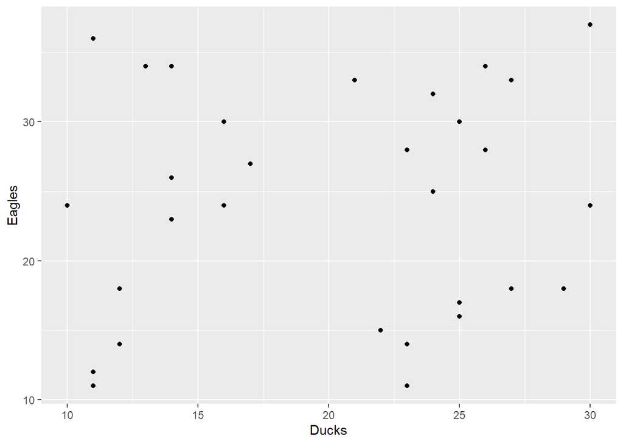

```r
scatter_plot<-wins_teams %>% select(Ducks, Eagles)%>%
  ggplot(aes(x=Ducks,y=Eagles))+geom_point()
scatter_plot
```

use **geom_smooth** to show the relationship of this scatter plot

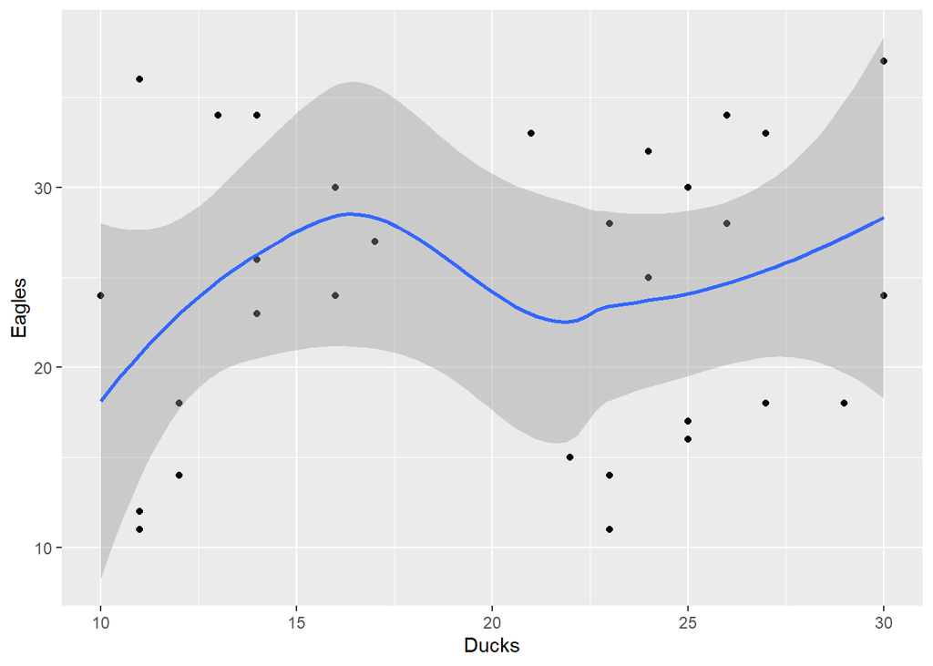

```r
# method to control curve type
scatter_plot+geom_smooth()
```

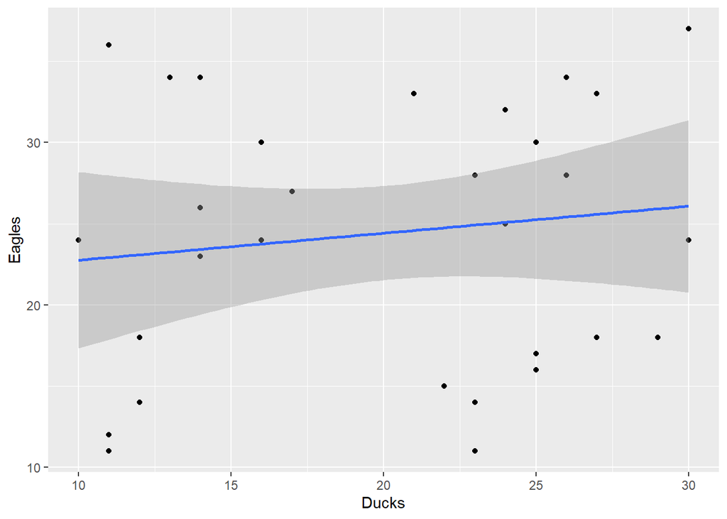

```r
scatter_plot+geom_smooth(method="glm")
```